# The Impact of Joel Embiid's Finger Injury

On January 6, Joel Embiid tore a ligament in the ring finger of his left hand in a game against the Oklahoma City Thunder. The play during which the injury occurred can be seen [here](https://stats.nba.com/events/?GameID=0021900541&Season=2019-20&GameEventID=133&flag=1&sct=plot) (images of the injury are pretty gruesome). The injury required surgery, resulting in Embiid missing nine games.

Since returning, Embiid has been playing with a fairly robust apparatus on his left hand for protection and to aid the healing process (images sourced from [sixers.com](https://www.nba.com/sixers/gallery/photos-76ers-vs-bulls-2920)).

[figure not shown]

```python
from IPython.display import display, Image
display(Image(filename='images/embiid1.jpg', width=600))
```

The following image shows more detail about how the apparatus is attached to his hand. The third and fourth fingers are constrained together with two smaller straps, with one larger strap wrapping around his palm. A bandage appears to cover the backside of his hand and wraps around his wrist.

[figure not shown]

```python
display(Image(filename='images/embiid_zoom.png', width=600))
```

Due to the sheer size of the apparatus, a reasonable thought would be that it may be impacting his shooting ability, as the introduction of any object attached to either hand could affect shooting. The following analysis tests explores this by examining Embiid's shooting from the field and the free throw line.

## Field Goal Shooting

The stats.nba.com site provides an offensive player's shooting performance by the distance to the closest defender. You can find Embiid's performance by defender distance bins for the 2019-20 season prior to his injury [here](https://stats.nba.com/player/203954/shots-dash/?Season=2019-20&SeasonType=Regular%20Season&PerMode=Totals&DateTo=01%2F07%2F2020&DateFrom=10%2F22%2F2019). The NBA defines these defender distance bins as follows:

- 0-2 feet (Very Tight)
- 2-4 feet (Tight)
- 4-6 feet (Open)
- 6+ feet (Wide Open)

With Very Tight shots making up the smallest portion of Embiid's frequency and the potential of those shots to be a poor indicator of shooting performance, the analysis excludes Very Tight shots. The following table shows the field goals made and attempted in the 31 games prior to the injury and the eight games following the injury.

```python
import pandas as pd
shooting_df = pd.DataFrame({'Timing': ['Pre-Injury', 'Post-Injury'],
                            'FGM': [216, 47],
                            'FGA': [460, 110],
                            'FG%': ['47.0%', '42.7%']})
shooting_df
```

|  | Timing | FGM | FGA | FG% |
| --- | --- | --- | --- | --- |
| 0 | Pre-Injury | 216 | 460 | 47.0% |
| 1 | Post-Injury | 47 | 110 | 42.7% |

Embiid is indeed shooting worse on shots that are not classified as Very Tight following his injury. However, the number of field goals attempted is less than 25% of the field goals attempted prior to the injury. Given this, how can one be sure if this sample size is large enough to conclude that the difference in shooting performance on these shots is significant?

Modeling field goal attempts as a Bernoulli process and leveraging [bootstrap hypothesis testing](https://en.wikipedia.org/wiki/Bootstrapping) can help. Essentially, this method allows for the comparison of each field goal percentage with unequal sample sizes to determine if the hypothesis that the field goal percentage before and after the injury are the same. This hypothesis is equivalent to the notion that the injury has not affected Embiid's shooting on these types of shots.

The following figure shows distributions of the FG% formed by 1000 samples with replacement from Embiid's attempted field goals.

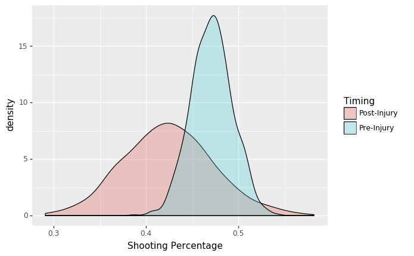

```python
display(Image(filename='images/fg.png', width=600))
```

The figure shows that, while the Pre-Injury distribution does have the bigger mean, the Post-Injury distribution is wider due to the smaller sample. This makes it difficult to conclude anything from the smaller observation of Embiid's shooting since returning. Indeed, the p-value from the bootstrap hypothesis testing is 0.21, meaning the hypothesis that the field goal percentage before and after the injury are the same cannot be rejected. In addition to the small sample, the above is only considering defender distance. Many aspects of the actual shots may have an impact on its actual difficulty, including shot type and distance. As such, a larger sample size should be required when considering shots from the field considering the many factors that affect the success of a field goal attempt.

## FT Shooting

Alternatively, free throw shooting does not have nearly as many factors impacting success. While fatigue could be one, examining free throws should isolate Embiid's shooting ability to determine any impact the injury may have. The following table shows the free throws made and attempted in the 31 games prior to the injury and the eight games following the injury.

```python
shooting_df = pd.DataFrame({'Timing': ['Pre-Injury', 'Post-Injury'],
                            'FTM': [211, 51],
                            'FTA': [252, 73],
                            'FT%': ['83.7%', '69.9%']})
shooting_df
```

|  | Timing | FTM | FTA | FT% |
| --- | --- | --- | --- | --- |
| 0 | Pre-Injury | 211 | 252 | 83.7% |
| 1 | Post-Injury | 51 | 73 | 69.9% |

Free throws can be modeled in the same manner as field goal attempts and the following figure shows distributions of the free throw percentage formed by 1000 samples with replacement from Embiid's attempted free throws.

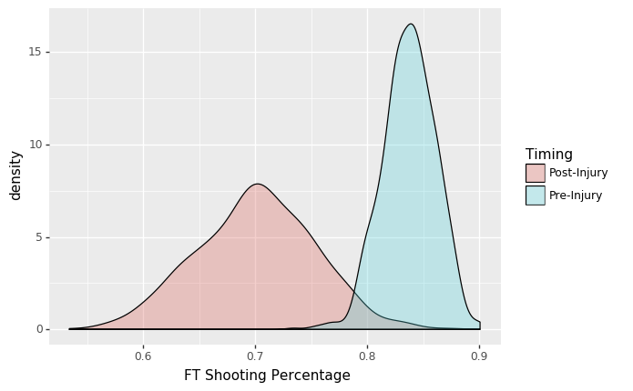

```python
display(Image(filename='images/ft.png', width=600))
```

This figure is much more compelling than the comparable field goal figure. The distribution of bootstrapped free throw percentage from Pre-Injury free throws is clearly greater than the Post-Injury distribution, despite the larger variance in the latter. This observation is supported by the p-value of 0.004 from the bootstrap hypothesis test, which is small enough to reject the hypothesis that the injury as no effect on free throw percentage at a 0.05 significance level. Given the above evidence, it is reasonable to consider that the injury and playing with the apparatus has affected Embiid's ability to shoot free throws.

## Takeaways

With the findings related to Joel Embiid's free throw shooting before and after his finger injury, a reasonable conclusion could be that the injury has had an effect on Embiid at the line. In fact, one could argue that the apparatus and any lingering effects from the injury are the only differences between trips to the line before and after the injury. Additionally, with the caveats stated in the analysis of field goal percentage, the free throw findings could indicate there is a possibility that shots from the field are affected as well, despite the lack of evidence.

This isn't to say that the 76ers rushed Embiid back to the court as this analysis only examines two small parts of Embiid's game. Future work could expand upon this analysis to study whether any other areas of his game have changed significantly. However, the above does show evidence that at least Embiid's performance from the line may have been negatively impacted.